# CRISPR sorting screen analysis method comparison

Carl de Boer

5/10/2020

## CRISPR sort-screen evaluation test

This document includes both the code and results for the evaluation metrics used in the MAUDE paper. This should allow fairly easy extension to allow new approaches and datasets.

```r
library(tidyverse)
library(cowplot)
library(MAUDE)
library(openxlsx)
library(edgeR)
library(DESeq2)
```

I forgot to set a seed when doing this for the publication, and there is an element of stochasticity in the evaluation, and so the final results are likely to differ a little from the publication, especially for the datasets with less signal/noise; if you run the stochastic steps multiple times, set a different seed, or don’t set the seed at all, they may also differ from this tutorial

```r
set.seed(35263377)
```

### CD69 screen

Load the CD69 data and process it.

```r
# a mapping to unify bin names from Simeonov data
binmapBack <- c(
  "baseline" = "baseline", "low" = "low", "medium" = "medium", "high" = "high",
  "back_"    = "NS",
  "baseline_" = "baseline", "low_" = "low", "medium_" = "medium", "high_" = "high",
  "A" = "baseline", "B" = "low", "E" = "medium", "F" = "high"
)

# this comes from manually reconstructing the CD69 density curve from extended data figure 1a (Simeonov et al)
binBoundsCD69 <- tibble(
  Bin      = c("A", "F", "B", "E"),
  fraction = c(0.65747100, 0.02792824, 0.25146688, 0.06313389)
)
fractionalBinBounds <- makeBinModel(binBoundsCD69[c("Bin", "fraction")]) |>
  bind_rows(makeBinModel(binBoundsCD69[c("Bin", "fraction")])) |>
  mutate(screen = rep(c("1", "2"), each = 6)) |>
  filter(Bin %in% c("A", "B", "E", "F")) |>
  mutate(Bin = binmapBack[Bin])
# load data
cd69OriginalResults <- read.xlsx(
  'NIHMS913084-supplement-supplementary_table_1.xlsx'
) |>
  mutate(
    NT  = grepl("negative_control", gRNA_systematic_name),
    pos = PAM_3primeEnd_coord
  ) |>
  distinct()

cd69CountData <- cd69OriginalResults |>
  dplyr::select(pos, NT, gRNA_systematic_name, matches("\\.count$")) |>
  pivot_longer(
    cols = -c(pos, NT, gRNA_systematic_name),
    names_to  = "variable",
    values_to = "reads"
  ) |>
  mutate(
    Bin  = gsub("CD69(.*)([12]).count", "\\1", variable),
    screen = gsub("CD69(.*)([12]).count", "\\2", variable),
    reads = as.numeric(reads),
    Bin = binmapBack[Bin])

binReadMat <- cd69CountData |>
  filter(!is.na(pos) | NT) |>
  pivot_wider(
    id_cols     = c(pos, gRNA_systematic_name, NT, screen),
    names_from  = Bin,
    values_from = reads
  )
```

I wanted to confirm that this is how they calculated logFC in Simeonov et al. The plot below should form a straight line on y=x.

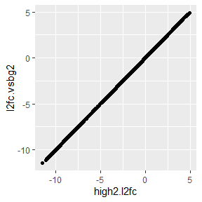

```r
# confirm how to calc log2FC:
cd69OriginalResults <- cd69OriginalResults |>
  mutate(
    l2fc.vsbg1 = log2((1 + CD69high_1.count.norm) / (1 + CD69back_1.count.norm)),
    l2fc.vsbg2 = log2((1 + CD69high_2.count.norm) / (1 + CD69back_2.count.norm)),
    l2fc.hilo1 = log2((1 + CD69high_1.count.norm) / (1 + CD69baseline_1.count.norm)),
    l2fc.hilo2 = log2((1 + CD69high_2.count.norm) / (1 + CD69baseline_2.count.norm))
  )

# confirm that how we just calculated log2 fc is the same as originally calculated
ggplot(cd69OriginalResults, aes(x = high2.l2fc, y = l2fc.vsbg2)) + geom_point()
```

Run the various analysis methods on the CD69 data.

```r
# edgeR
x <- cd69OriginalResults |>
  select(gRNA_systematic_name, CD69baseline_1.count, CD69baseline_2.count,
         CD69high_1.count, CD69high2.count) |>
  distinct() |>
  column_to_rownames("gRNA_systematic_name") |>
  as.matrix()

group  <- factor(c(1, 1, 2, 2))
y      <- DGEList(counts = x, group = group)
y      <- calcNormFactors(y)
design <- model.matrix(~group)
y      <- estimateDisp(y, design)
fit    <- glmFit(y, design)
lrt    <- glmLRT(fit, coef = 2)

edgeRGuideLevel <- topTags(lrt, n = nrow(x))@.Data[[1]] |>
  rownames_to_column("gRNA_systematic_name") |>
  mutate(metric = logFC, significance = -log(PValue), method = "edgeR")

# DESeq2
deseqGroups <- data.frame(
  bin = factor(c(1, 1, 2, 2)),
  row.names = c("CD69baseline_1.count", "CD69baseline_2.count",
                "CD69high_1.count", "CD69high2.count")
)
dds <- DESeqDataSetFromMatrix(countData = x, colData = deseqGroups, design = ~bin)
dds <- DESeq(dds)
res <- results(dds, name = resultsNames(dds)[2])

deseqGuideLevel <- as.data.frame(res@listData) |>
  mutate(
    gRNA_systematic_name = res@rownames,
    metric       = log2FoldChange,
    significance = -log(pvalue),
    method       = "DESeq2"
  )

# MAUDE
guideLevelStatsCD69 <- findGuideHitsAllScreens(
  distinct(binReadMat["screen"]), binReadMat, fractionalBinBounds,
  sortBins = c("baseline", "high", "low", "medium"), unsortedBin = "NS"
)
guideLevelStatsCD69$chr <- "chr12"

guideLevelStatsCastCD69 <- guideLevelStatsCD69 |>
  pivot_wider(
    id_cols     = c(gRNA_systematic_name, pos, NT),
    names_from  = screen,
    values_from = Z,
    names_prefix = "s"           # produces s1, s2
  ) |>
  mutate(
    significance = apply(pick(s1, s2), 1, combineZStouffer),
    metric       = rowMeans(pick(s1, s2)),
    method       = "MAUDE"
  )

# Two log fold change methods
cd69OriginalResultsHiLow <- cd69OriginalResults |>
  select(gRNA_systematic_name, l2fc.hilo1, l2fc.hilo2) |>
  mutate(
    significance = rowMeans(pick(l2fc.hilo1, l2fc.hilo2)),
    metric       = rowMeans(pick(l2fc.hilo1, l2fc.hilo2)),
    method       = "logHivsLow"
  )

cd69OriginalResultsVsBG <- cd69OriginalResults |>
  select(gRNA_systematic_name, l2fc.vsbg1, l2fc.vsbg2) |>
  mutate(
    significance = rowMeans(pick(l2fc.vsbg1, l2fc.vsbg2)),
    metric       = rowMeans(pick(l2fc.vsbg1, l2fc.vsbg2)),
    method       = "logVsUnsorted"
  )
```

Compile the results from the various methods.

```r
keep_cols <- c("method", "gRNA_systematic_name", "significance", "metric")

allResults <- bind_rows(
  select(cd69OriginalResultsVsBG,  all_of(keep_cols)),
  select(cd69OriginalResultsHiLow, all_of(keep_cols)),
  select(deseqGuideLevel,          all_of(keep_cols)),
  select(edgeRGuideLevel,          all_of(keep_cols)),
  select(guideLevelStatsCastCD69,  all_of(keep_cols))
) |>
  left_join(
    distinct(cd69OriginalResults, gRNA_systematic_name, NT, pos),
    by = "gRNA_systematic_name"
  ) |>
  filter(!is.na(pos) | NT) |>
  mutate(
    promoter  = pos <= 9913996 & pos >= 9912997,
    gID       = gRNA_systematic_name,
    locus     = "CD69",
    type      = "CRISPRa",
    celltype  = "Jurkat"
  ) |>
  select(-gRNA_systematic_name)
```

### TNFAIP3

Load and parse the TNFAIP3 data from Ray et al.

```r
read_gz_table <- function(url_str) {
  read.table(
    textConnection(readLines(gzcon(url(url_str)))),
    sep = "\t", stringsAsFactors = FALSE, header = TRUE
  )
}

base_url <- "https://ftp.ncbi.nlm.nih.gov/geo/series/GSE136nnn/GSE136693/suppl"
binFractionsA20  <- read_gz_table(file.path(base_url, "GSE136693_20190828_CRISPR_FF_bin_fractions.txt.gz"))
CRISPRaCountsA20 <- read_gz_table(file.path(base_url, "GSE136693_20190828_CRISPRa_FF_countMatrix.txt.gz"))
CRISPRiCountsA20 <- read_gz_table(file.path(base_url, "GSE136693_20190828_CRISPRi_FF_countMatrix.txt.gz"))
crispraGuides    <- read_gz_table(file.path(base_url, "GSE136693_20180205_selected_CRISPRa_guides_seq.txt.gz"))

parse_guide_pos <- function(id_vec) {
  round((as.numeric(gsub("([0-9]+):([0-9]+)-([0-9]+):([+-])", "\\2", id_vec)) +
           as.numeric(gsub("([0-9]+):([0-9]+)-([0-9]+):([+-])", "\\3", id_vec))) / 2)
}

crispraGuides <- crispraGuides |>
  mutate(
    seq = gsub("(.*)(.{3})", "\\1", seq.w.PAM),
    pos = parse_guide_pos(guideID)
  )

CRISPRaCountsA20 <- left_join(
  CRISPRaCountsA20,
  crispraGuides |> dplyr::group_by(seq) |> dplyr::summarise(pos = pos[1], .groups = "drop"),
  by = "seq"
)

CRISPRiCountsA20 <- mutate(CRISPRiCountsA20, pos = parse_guide_pos(gID))
binFractionsA20  <- mutate(binFractionsA20, expt = paste(celltype, CRISPRType, sep = "_"))

# merge CRISPRi and CRISPRa into long format
# gID is integer in CRISPRa and character in CRISPRi — coerce both to character first
id_vars <- c("seq", "elementClass", "element", "NT", "gID", "pos")
A20CountData <- bind_rows(
  pivot_longer(mutate(CRISPRaCountsA20, gID = as.character(gID)),
               -all_of(id_vars), names_to = "sample", values_to = "count") |>
    mutate(CRISPRType = "CRISPRa"),
  pivot_longer(mutate(CRISPRiCountsA20, gID = as.character(gID)),
               -all_of(id_vars), names_to = "sample", values_to = "count") |>
    mutate(CRISPRType = "CRISPRi")
) |>
  mutate(
    bin      = gsub("(.*)_(.*)_(.*)", "\\3", sample),
    screen   = gsub("(.*)_(.*)_(.*)", "\\2", sample),
    celltype = gsub("(.*)_(.*)_(.*)", "\\1", sample),
    expt     = paste(celltype, CRISPRType, sep = "_")
  ) |>
  select(-sample)
```

Run each method on each experiment from Ray et al.

```r
# combine CD69 metrics
# Pearson's r between replicates — metricsBoth will contain all our evaluation metrics
cd69_non_nt <- filter(guideLevelStatsCastCD69, !NT)
metricsBoth <- tibble(
  method = c("MAUDE", "logHivsLow", "logVsUnsorted"),
  metric = "r",
  which  = "replicate_correl",
  value  = c(
    cor(cd69_non_nt$s1, cd69_non_nt$s2),
    cor(cd69OriginalResults$l2fc.hilo1[!cd69OriginalResults$NT],
        cd69OriginalResults$l2fc.hilo2[!cd69OriginalResults$NT]),
    cor(cd69OriginalResults$l2fc.vsbg1[!cd69OriginalResults$NT],
        cd69OriginalResults$l2fc.vsbg2[!cd69OriginalResults$NT])
  ),
  sig = c(
    cor.test(cd69_non_nt$s1, cd69_non_nt$s2)$p.value,
    cor.test(cd69OriginalResults$l2fc.hilo1[!cd69OriginalResults$NT],
             cd69OriginalResults$l2fc.hilo2[!cd69OriginalResults$NT])$p.value,
    cor.test(cd69OriginalResults$l2fc.vsbg1[!cd69OriginalResults$NT],
             cd69OriginalResults$l2fc.vsbg2[!cd69OriginalResults$NT])$p.value
  ),
  locus    = "CD69",
  type     = "CRISPRa",
  celltype = "Jurkat"
)

allResultsBoth <- allResults  # combined results for CD69 and A20 screens

for (e in unique(binFractionsA20$expt)) {
  curCelltype <- gsub("(.*)_(.*)", "\\1", e)
  curtype     <- gsub("(.*)_(.*)", "\\2", e)

  curA20CountData <- A20CountData |>
    filter(expt == e) |>
    distinct(seq, pos, NT, gID, count, screen, bin)

  # compute CPM
  curA20CountData <- curA20CountData |>
    group_by(screen, bin) |>
    mutate(CPM = count / sum(count) * 1e6) |>
    ungroup()

  curCPMMat <- curA20CountData |>
    pivot_wider(
      id_cols     = c(seq, NT, gID, screen, pos),
      names_from  = bin,
      values_from = CPM
    ) |>
    mutate(
      l2fc_hilo = log2((1 + F) / (1 + A)),
      l2fc_vsbg = if (curtype == "CRISRPi") {
        log2((1 + NS) / (1 + A))
      } else {
        log2((1 + F) / (1 + NS))
      }
    )

  # build bin model per screen
  curBins <- binFractionsA20 |>
    filter(expt == e) |>
    pivot_longer(
      cols      = -c(celltype, screen, CRISPRType, expt),
      names_to  = "Bin",
      values_to = "fraction"
    )

  curBins2 <- curBins |>
    group_by(screen) |>
    group_modify(~ makeBinModel(.x[c("Bin", "fraction")])) |>
    ungroup() |>
    mutate(Bin = as.character(Bin))

  curCountMat <- curA20CountData |>
    pivot_wider(
      id_cols     = c(seq, NT, gID, pos, screen),
      names_from  = bin,
      values_from = count
    )

  guideLevelStats <- findGuideHitsAllScreens(
    experiments    = distinct(curCountMat, screen),
    countDataFrame = curCountMat,
    binStats       = curBins2,
    sortBins       = c("A", "B", "C", "D", "E", "F"),
    unsortedBin    = "NS",
    negativeControl = "NT"
  )

  maudeZs <- guideLevelStats |>
    pivot_wider(
      id_cols    = c(gID, pos, NT),
      names_from = screen,
      values_from = Z
    )

  sampleNames <- unique(curA20CountData$screen)

  guideLevelStatsCast <- maudeZs |>
    mutate(
      significance = apply(pick(all_of(sampleNames)), 1, combineZStouffer),
      metric       = rowMeans(pick(all_of(sampleNames))),
      method       = "MAUDE"
    )

  ### EdgeR
  x_edger <- curA20CountData |>
    filter(bin %in% c("A", "F")) |>
    distinct(bin, gID, screen, count) |>
    pivot_wider(
      id_cols     = gID,
      names_from  = c(screen, bin),
      values_from = count
    ) |>
    column_to_rownames("gID") |>
    as.matrix()

  group_edger <- factor(grepl("_F", colnames(x_edger)) + 1)
  y      <- DGEList(counts = x_edger, group = group_edger)
  y      <- calcNormFactors(y)
  design <- model.matrix(~group_edger)
  y      <- estimateDisp(y, design)
  fit    <- glmFit(y, design)
  lrt    <- glmLRT(fit, coef = 2)

  edgeRGuideLevel <- topTags(lrt, n = nrow(x_edger))@.Data[[1]] |>
    rownames_to_column("gID") |>
    mutate(metric = logFC, significance = -log(PValue), method = "edgeR")

  ### DESeq2
  deseqGroups <- data.frame(bin = group_edger, row.names = colnames(x_edger))
  dds <- DESeqDataSetFromMatrix(countData = x_edger, colData = deseqGroups, design = ~bin)
  dds <- DESeq(dds)
  stopifnot(resultsNames(dds)[1] == "Intercept")
  res <- results(dds, name = resultsNames(dds)[2])

  deseqGuideLevel <- as.data.frame(res@listData) |>
    mutate(
      gID          = res@rownames,
      metric       = log2FoldChange,
      significance = -log(pvalue),
      method       = "DESeq2"
    )

  # log fold change methods: wide → compute mean across replicate columns
  curLRHiLow <- curCPMMat |>
    distinct(gID, NT, screen, l2fc_hilo) |>
    pivot_wider(id_cols = c(gID, NT), names_from = screen, values_from = l2fc_hilo) |>
    mutate(
      significance = rowMeans(pick(all_of(sampleNames))),
      metric       = rowMeans(pick(all_of(sampleNames))),
      method       = "logHivsLow"
    )

  curLRVsBG <- curCPMMat |>
    distinct(gID, NT, screen, l2fc_vsbg) |>
    pivot_wider(id_cols = c(gID, NT), names_from = screen, values_from = l2fc_vsbg) |>
    mutate(
      significance = rowMeans(pick(all_of(sampleNames))),
      metric       = rowMeans(pick(all_of(sampleNames))),
      method       = "logVsUnsorted"
    )

  # compile results for A20
  keep_cols_a20 <- c("method", "gID", "significance", "metric")
  curResults <- bind_rows(
    distinct(curLRHiLow, across(all_of(keep_cols_a20))),
    distinct(curLRVsBG,  across(all_of(keep_cols_a20))),
    select(deseqGuideLevel,    all_of(keep_cols_a20)),
    select(edgeRGuideLevel,    all_of(keep_cols_a20)),
    distinct(guideLevelStatsCast, across(all_of(keep_cols_a20)))
  ) |>
    left_join(distinct(curCPMMat, gID, NT, pos), by = "gID") |>
    filter(!is.na(pos) | NT) |>
    mutate(
      promoter = grepl("TNFAIP3", gID) | (pos <= 138189439 & pos >= 138187040),
      locus    = "TNFAIP3",
      type     = curtype,
      celltype = curCelltype
    )

  allResultsBoth <- bind_rows(allResultsBoth, curResults)

  # (1) inter-replicate correlation — find the best pair
  best_cor <- function(wide_df, cols) {
    best_r <- -1; best_p <- 1
    non_nt <- filter(wide_df, !NT)
    for (i in seq_len(length(cols) - 1)) {
      for (j in (i + 1):length(cols)) {
        r <- cor(non_nt[[cols[i]]], non_nt[[cols[j]]])
        p <- cor.test(non_nt[[cols[i]]], non_nt[[cols[j]]])$p.value
        if (r > best_r) { best_r <- r; best_p <- p }
      }
    }
    list(r = best_r, p = best_p)
  }

  bc_maude <- best_cor(maudeZs,   sampleNames)
  bc_hilo  <- best_cor(curLRHiLow, sampleNames)
  bc_vsbg  <- best_cor(curLRVsBG,  sampleNames)

  metricsBoth <- bind_rows(metricsBoth, tibble(
    method   = c("MAUDE", "logHivsLow", "logVsUnsorted"),
    metric   = "r",
    which    = "replicate_correl",
    value    = c(bc_maude$r, bc_hilo$r, bc_vsbg$r),
    sig      = c(bc_maude$p, bc_hilo$p, bc_vsbg$p),
    locus    = "TNFAIP3",
    type     = curtype,
    celltype = curCelltype
  ))
}
```

Here are some functions that I will make use of below.

```r
ranksumROC <- function(x, y, na.rm = TRUE, ...) {
  if (na.rm) {
    x <- x[!is.na(x)]
    y <- y[!is.na(y)]
  }
  curTest        <- wilcox.test(x, y, ...)
  curTest$AUROC  <- (curTest$statistic / length(x)) / length(y)
  curTest
}
```

### Evaluation

The inter-replicate correlations were calculated in the sections above and are stored in `metricsBoth`. Below, the two remaining metrics are calculated (distinguishing promoter vs other targeting guides, and adjacent vs randomly paired guides).

```r
# (1) similarity between the effect sizes estimated per replicate (above)
metricsBoth <- mutate(metricsBoth, significant = sig < 0.01)

# Other evaluation metrics
allExpts <- distinct(allResultsBoth, celltype, locus, type)

for (ei in seq_len(nrow(allExpts))) {
  curCelltype <- allExpts$celltype[ei]
  curtype     <- allExpts$type[ei]
  curLocus    <- allExpts$locus[ei]

  curResults <- allResultsBoth |>
    filter(celltype == curCelltype, type == curtype, locus == curLocus)

  for (m in unique(curResults$method)) {
    curData <- curResults |>
      filter(method == m, !NT) |>
      arrange(pos)

    # (2) similarity in effect size between adjacent guides
    guideEffectDistances <- tibble(
      method     = m,
      random     = FALSE,
      difference = abs(diff(curData$metric)),
      dist       = abs(diff(curData$pos))
    ) |>
      filter(dist < 100) |>
      select(-dist)

    ### changed 10 to 100 to make this more robust
    curDataSampled <- curData[sample(nrow(curData), size = nrow(curData) * 100, replace = TRUE), ]
    guideEffectDistances <- bind_rows(
      guideEffectDistances,
      tibble(
        method     = m,
        random     = TRUE,
        difference = abs(diff(curDataSampled$metric))
      )
    )

    # random should have more different than adjacent
    curRS <- ranksumROC(
      guideEffectDistances$difference[guideEffectDistances$random],
      guideEffectDistances$difference[!guideEffectDistances$random]
    )
    metricsBoth <- bind_rows(metricsBoth, tibble(
      method      = m, metric = "AUROC-0.5", which = "adjacent_vs_random",
      value       = curRS$AUROC - 0.5, locus = curLocus,
      celltype    = curCelltype, type = curtype,
      sig         = curRS$p.value, significant = curRS$p.value < 0.01
    ))

    # (3) ability to distinguish promoter-targeting guides from other guides.
    if (curtype == "CRISPRi" & !(m %in% c("edgeR", "DESeq2"))) {
      # edgeR and DESeq2 are reversed for CRISPRi
      # non-promoter should have higher effect than promoter (more -ve)
      curRS <- ranksumROC(
        curResults$significance[curResults$method == m & !curResults$NT & !curResults$promoter],
        curResults$significance[curResults$method == m & !curResults$NT &  curResults$promoter]
      )
    } else {
      # promoter should have larger effect than non-promoter
      curRS <- ranksumROC(
        curResults$significance[curResults$method == m & !curResults$NT &  curResults$promoter],
        curResults$significance[curResults$method == m & !curResults$NT & !curResults$promoter]
      )
    }
    metricsBoth <- bind_rows(metricsBoth, tibble(
      method      = m, metric = "AUROC-0.5", which = "promoter_vs_T",
      value       = curRS$AUROC - 0.5, locus = curLocus,
      celltype    = curCelltype, type = curtype,
      sig         = curRS$p.value, significant = curRS$p.value < 0.01
    ))
  }
}

## compile all metrics; label the best in each test and whether any tests were significant (P<0.01)
method_levels <- c("logVsUnsorted", "logHivsLow", "DESeq2", "edgeR", "MAUDE")

metricsBoth2 <- metricsBoth |>
  mutate(method = factor(as.character(method), levels = method_levels)) |>
  group_by(which, locus, type, celltype) |>
  mutate(
    best    = max(value, na.rm = TRUE),
    anySig  = any(significant)
  ) |>
  ungroup() |>
  mutate(
    isBest   = value == best,
    isBestNA = if_else(isBest, TRUE, NA),
    pctOfMax = value / best * 100
  )

# fill in NAs for edgeR and DESeq2 which cannot have inter-replicate correlations
na_rows <- metricsBoth2 |>
  dplyr::filter(metric == "r") |>
  dplyr::slice(1:2) |>
  dplyr::mutate(
    method      = factor(c("edgeR", "DESeq2"), levels = method_levels),
    value       = NA_real_,
    isBest      = NA,
    significant = FALSE,
    pctOfMax    = NA_real_,
    isBestNA    = NA
  )
metricsBoth2 <- dplyr::bind_rows(metricsBoth2, na_rows)
```

Finally make the graph with all evaluation metrics as shown in the MAUDE paper.

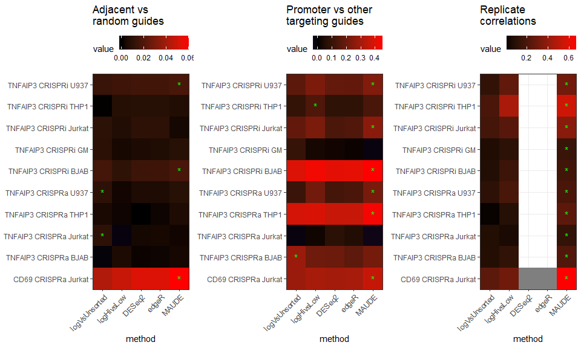

```r
make_tile_plot <- function(data, title_str) {
  ggplot(data, aes(x = method, fill = value, y = paste(locus, type, celltype))) +
    geom_tile() +
    geom_text(
      data = filter(data, anySig),
      aes(label = "*", colour = isBestNA), show.legend = FALSE
    ) +
    scale_fill_gradient2(high = "red", low = "blue", mid = "black") +
    scale_colour_manual(values = c("green"), na.value = NA) +
    scale_y_discrete(expand = c(0, 0)) +
    scale_x_discrete(expand = c(0, 0)) +
    theme_bw() +
    theme(
      legend.position = "top",
      axis.text.x     = element_text(hjust = 1, angle = 45),
      axis.title.y    = element_blank()
    ) +
    ggtitle(title_str)
}

p1 <- make_tile_plot(filter(metricsBoth2, which == "adjacent_vs_random"), "Adjacent vs\nrandom guides")
p2 <- make_tile_plot(filter(metricsBoth2, which == "promoter_vs_T"),      "Promoter vs other\ntargeting guides")
p3 <- make_tile_plot(filter(metricsBoth2, which == "replicate_correl"),   "Replicate\ncorrelations")

plot_grid(p1, p2, p3, align = "h", nrow = 1)
```